# An introduction to the ATM99 model in R

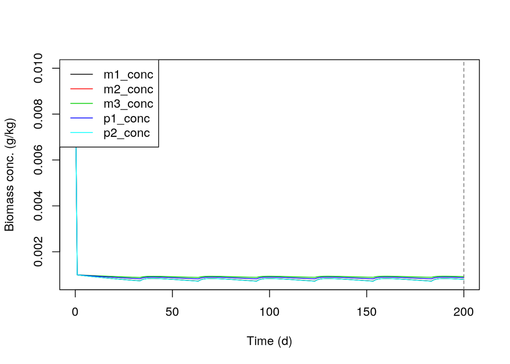

```r
matplot(out9$time, out9[, nn <- c('m1_conc', 'm2_conc', 'm3_conc', 'p1_conc', 'p2_conc')],
        type = 'l', lty = 1, xlab = 'Time (d)', ylab = 'Biomass conc. (g/kg)')
legend('topleft', nn, col = 1:5, lty = 1)
abline(v = pH_dat$time, lty = 2, col = 'gray45')
```

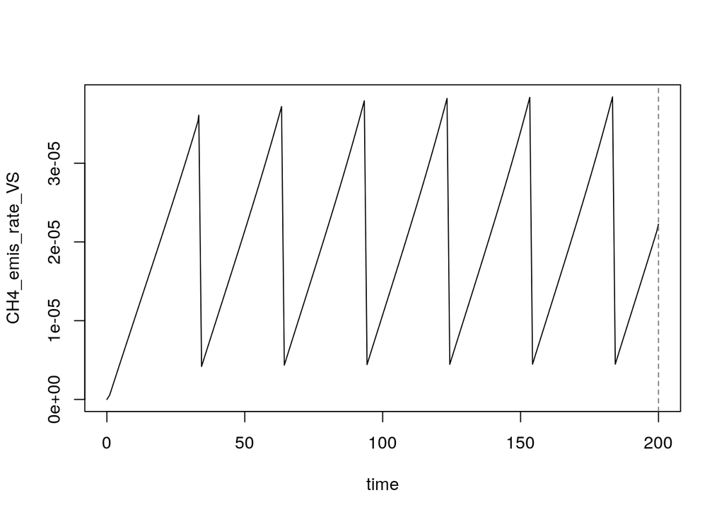

```r
plot(CH4_emis_rate_VS ~ time, data = out9, type = 'l')
abline(v = pH_dat$time, lty = 2, col = 'gray45')
```

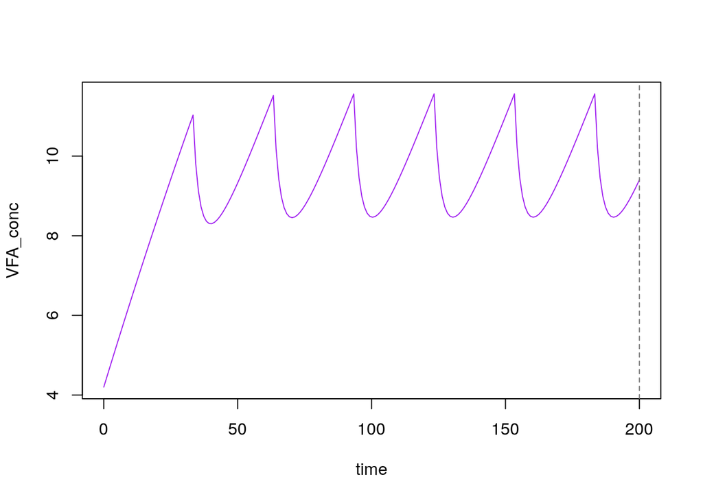

```r
plot(VFA_conc ~ time, type = 'l', col = 'purple', data = out9)
abline(v = pH_dat$time, lty = 2, col = 'gray45')
```

NTS: This is a difficult approach and the titration curve needs another look.

# 9. Model output as input

Although the `atm()` function is quite flexible and can accommodate changes in inputs over time, there is plenty it cannot do. To partially address limitations, it is possible to specify output from one call as the starting conditions for a new call. This is done using the `starting` argument. In the following example, two calls are used to show the effect of an instant change in the substrate concentration in fresh slurry.

```r
out10 <- atm(365, 1, add_pars = list(conc_fresh.Sp = 100, conc_fresh.COD = 200, conc_fresh.VFA = 10))
```

```r
out11 <- atm(365, 1, add_pars = list(conc_fresh.Sp = 10, conc_fresh.COD = 20, conc_fresh.VFA = 0),
             starting = out10)
```

```
## Using starting conditions from `starting` argument
```

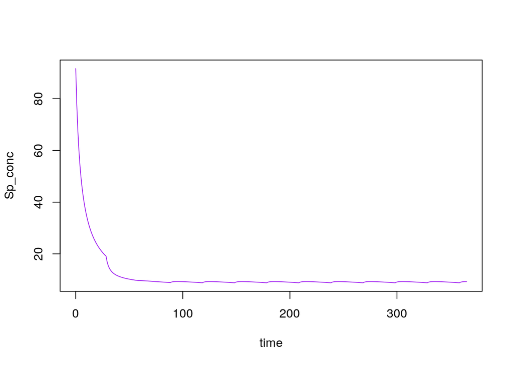

```r
plot(Sp_conc ~ time, type = 'l', col = 'purple', data = out11)
```

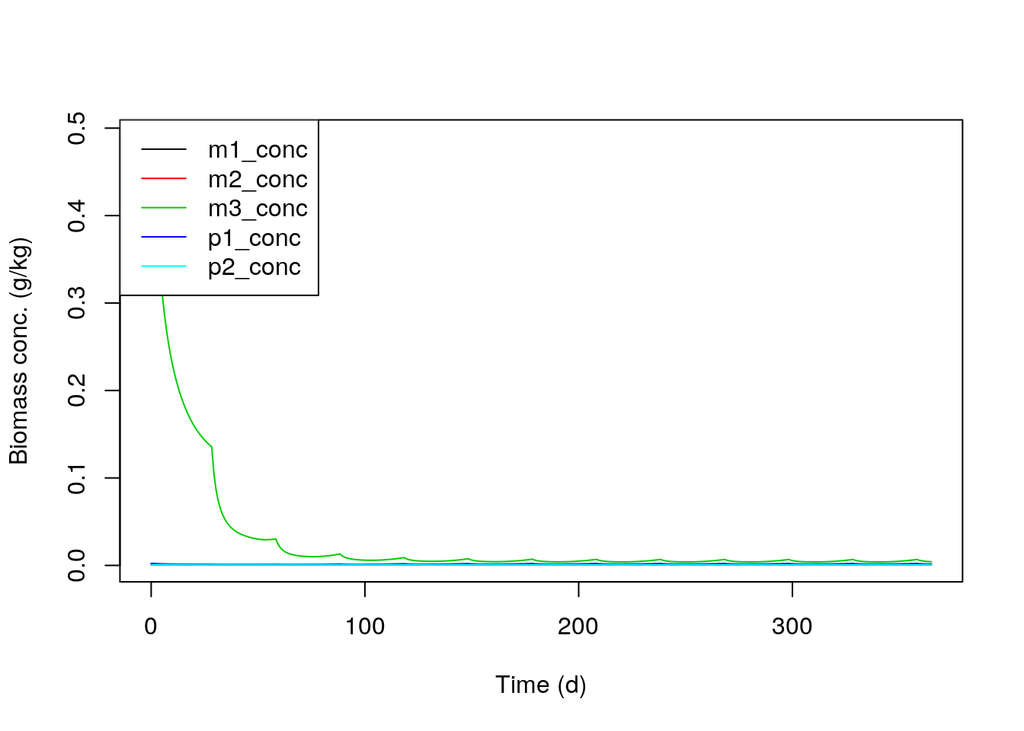

```r
matplot(out11$time, out11[, nn <- c('m1_conc', 'm2_conc', 'm3_conc', 'p1_conc', 'p2_conc')],
        type = 'l', lty = 1, xlab = 'Time (d)', ylab = 'Biomass conc. (g/kg)')
legend('topleft', nn, col = 1:5, lty = 1)
```

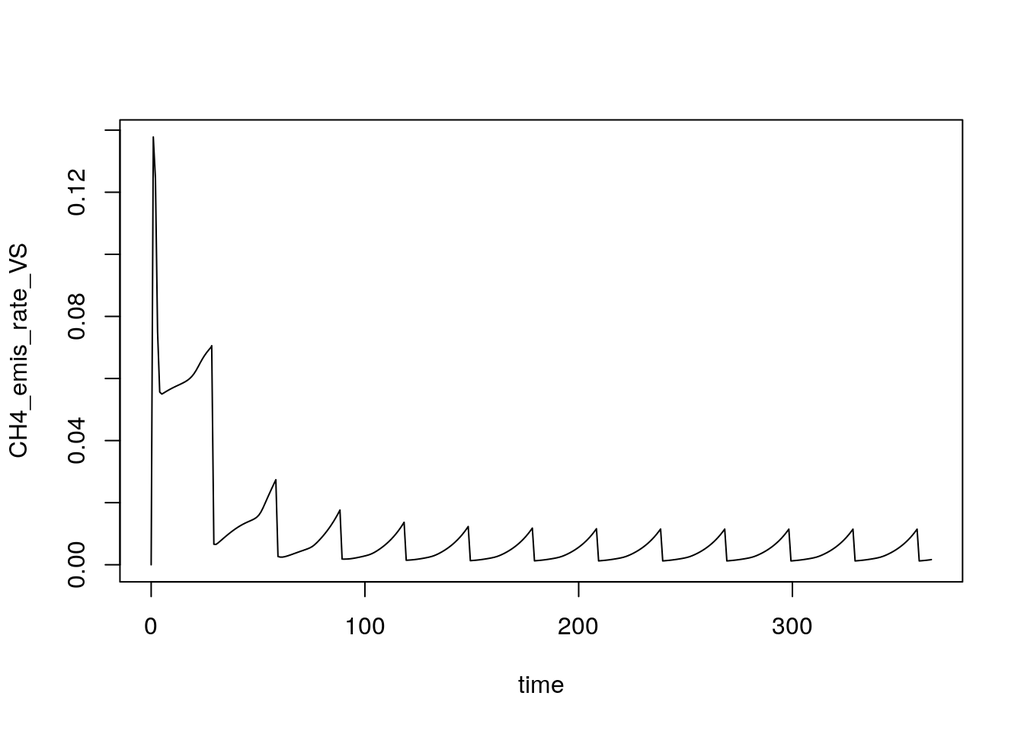

```r
plot(CH4_emis_rate_VS ~ time, data = out11, type = 'l')
```

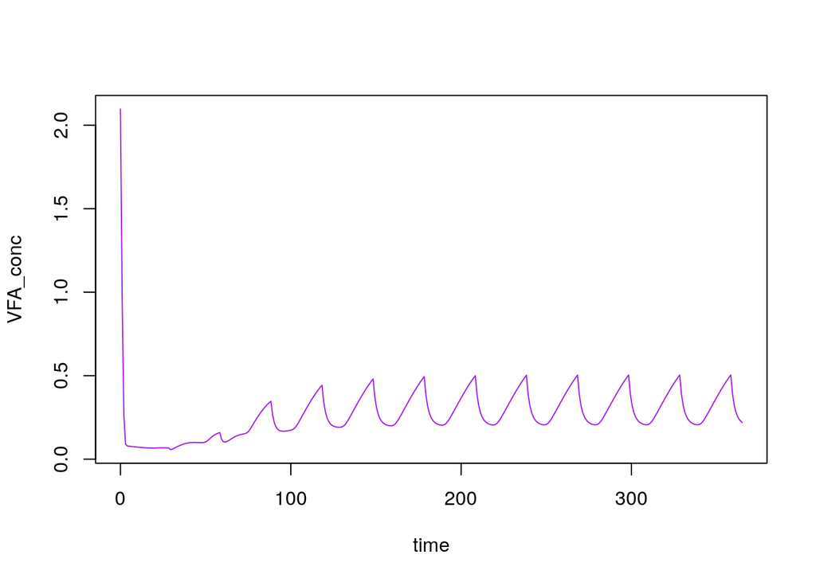

```r
plot(VFA_conc ~ time, type = 'l', col = 'purple', data = out11)
```

# 10. More information